# Red Wine Quality

#### Quality vs. Density and Residual Sugar

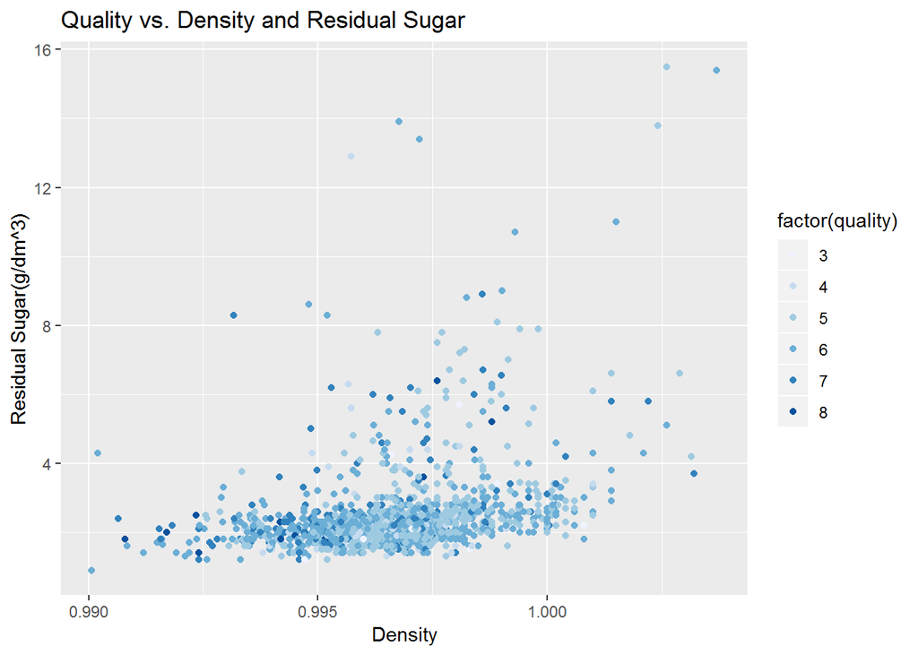

#### Quality vs. Acidity and Statistical Summary

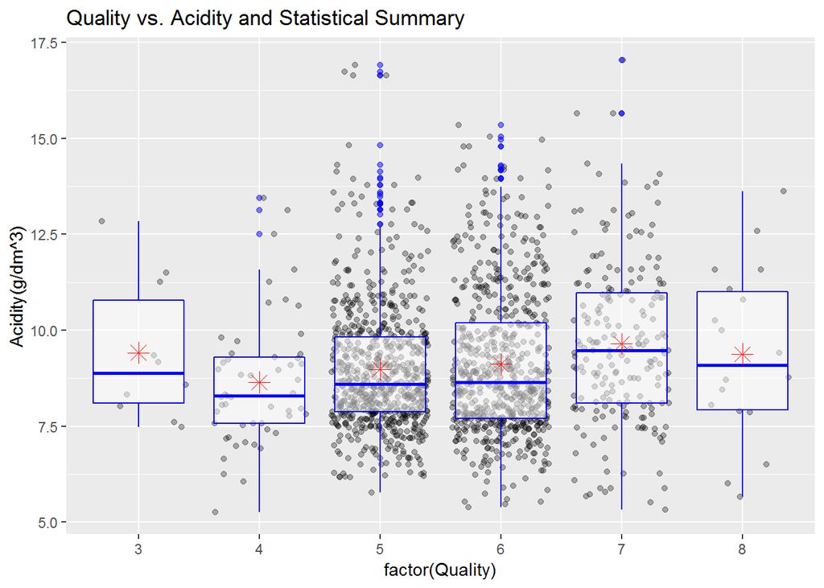

### Multivariate Plot Section Analysis:

#### Were there any interesting or surprising interactions between features?

Most of the features were resulted as expected.

## Final Plots and Summary Section:

### Plot 1:

The plot shows the correlation between Quality and Citric Acid and Sulphates

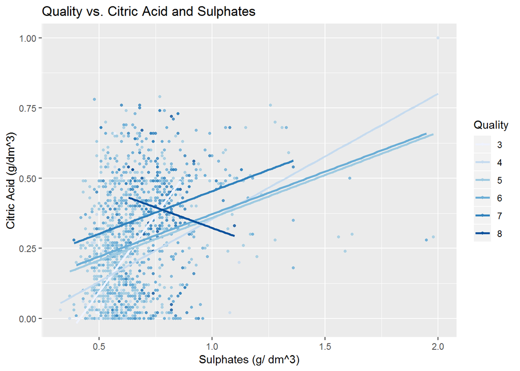

### Plot 2:

The next plot shows the correlation between Quality and Alcohol and Statistical Summary.

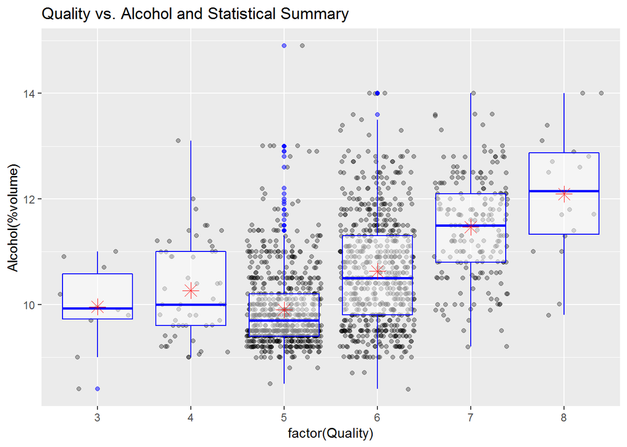

### Description Plot 2:

I selected this plot due to the importance of this feature to the quality of the red wine, as its have the highest positive correlation with the quality variable. The graph represents the factors of quality influenced by the Alcohol and the avarage of Alcohol in each factor of quality. It shows that the quality of red wine increases when Alcohol increase, as well as increasing in the avarage in each factor. As the influence appeared in the range of (8% to 13%) of Alcohol volume and high influence in fifth and sixth factor of Quality.

### Plot 3:

This plot shows the correlation of Volatile Acidity and Total Sulfur Dioxide with Quality.

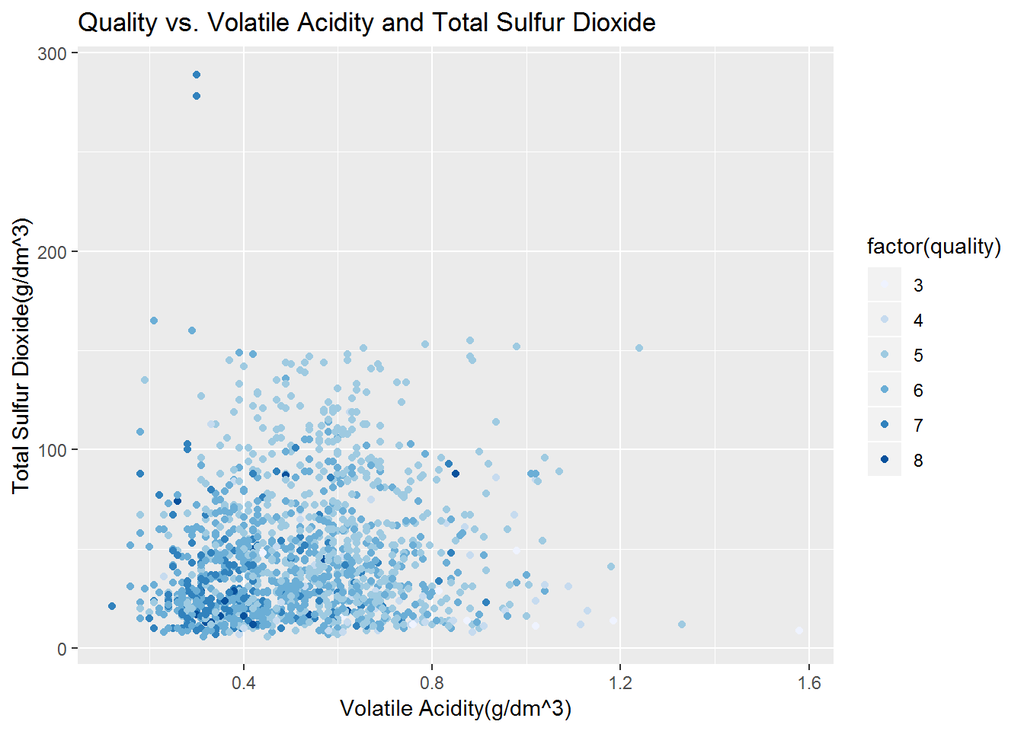

### Description Plot 3:

In this plot I combined the lowest correlation coefficient features with the quality variable. The graph represents the features influenced in the red wine quality, which are Volatile Acidity and Total Sulfur Dioxide. It shows that the quality decreases when Volatile Acidity and Total Sulfur Dioxide increase. As most of the high quality lay on the range of (100 g/dm^3) in Total Sulfur Dioxide and (0.5 g/dm^3) of Volatile Acidity

## Reflection:

The object of this exploratory data analysis is to find out which chemical properties would afftect the quality of red wines. So, We went throught the dataset in overview then exploring each variable (Univariate Analysis), after that we tried to have a look in the relationship of Quality and the other variables, on the other hand, the relationship betwen different variables (Bivariate Analysis), in the end of the exploring and analyzing process, we tried to explore 2 or more variables relationship with Quality (Multivariate Analysis) .

The results of exploring and analyzing this dataset concluding that there are some features had positive correlation such as Alcohol (the highest correlation coefficient) and others had negative correlation such as Volatile Acidity (the lowest correlation coefficient) which influenced the Quality of red wine.

However, after all these analysis, we found none of the correlation coefficient were above 0.5 which means that the correlation of quality and other features is weak overall.

In this extent, we have to say that the measure of red wine quality is subjective, which means the data analysis is not enough to reveal all factors and to rate a red wine.

On the other hand, we observed that more than 80% of red wine features are existed in quality rate of 5 and 6 , this limitation makes that there is not enough data to analyze good wine’s factors. In furter analysis, a dataset has more observations will be preferred.

#### References:

- Github Respositories.
- Tensorflow.
- Youtube.